# Agricultural Transition: Heart of SW LEP

Robert Berry

25 January, 2022

The aim of this website is to report the ongoing geospatial data analysis for the CCRI’s Agricultural Transition: Heart of South West LEP project. All of the tables and plots shown on this website can also be accessed as individual files [HERE](https://connectglosac.sharepoint.com/:f:/s/ccriprojects/EkmH8fOBINtNlhpJy_J-mqIBYQEk-p6fjgTJec68p_ji6A?e=hn0WaW). The full [R programming](https://www.r-project.org/about.html) code used to perform the work is included in this report, and can be accessed by clicking on the “Code” buttons. Even if you are unfamiliar with R code, comments (in plain English) have been added to describe the operation of each code block, so it should be possible to follow the methodology.

## 1. Pillar 1: County-level

This section shows the code and outputs for the analysis of Pillar 1 (P1) payments at county level (for the counties of **Cornwall**, **Devon**, **Dorset**, and **Somerset**)

### 1.1 Data import & cleaning

Import and cleaning of the CAP Payments (data source: [HERE](https://cap-payments.defra.gov.uk/Search.aspx))

**Step 1** - Load code packages and import data

```
#> 1.1.1 Load libraries
```

```r
library(tidyverse) # data munging and analysis
library(sf) # simple features for GIS
library(qgisprocess) # access to QGIS algorithms
library(here) # relative path management for reproducibility
library(lubridate) # for date string manipulation/conversion
library(janitor) # data cleaning functions
library(knitr) # report rendering with rmarkdown
library(ggplot2) # plots and visualisations
library(readxl) # import xls
library(scales) # for plot scale customisation
library(mapproj) # map zoom coords
rpa.1 <- readxl::read_xlsx(here("In", "BPS_Glos", "2020_All_CAP_Search_Results_Data_P14.xlsx"), trim_ws = TRUE, sheet = "RPA")
```

```
#> "RPA2" sheet
```

```r
rpa.2 <- readxl::read_xlsx(here("In", "BPS_Glos", "2020_All_CAP_Search_Results_Data_P14.xlsx"), trim_ws = TRUE, sheet = "RPA2")
```

**Step 2** - Data cleaning and pre-processing

```
#> 1.1.3 Data cleaning and pre-processing
```

```
#> Bind the two RPA tables together (they are split alphabetically by beneficiary name)
```

```r
db <- rbind(rpa.1, rpa.2)
```

```
#> Remove duplicates
```

```r
db <- db %>%
  distinct()
```

```
#> Remove any empty records where all columns are "NA"
```

```r
# Following filters rows with at least one column not "NA"
db <- janitor::remove_empty(db, which = "rows")
```

```
#> Select only relevant rcolumns
```

```r
db <- db %>%
  select("BeneficiaryCode", "PostcodePrefix_F202B", "TownCity_F202C", "Basic payment scheme", "Greening: practices beneficial for climate and environment") |>
  arrange(desc(`Basic payment scheme`))
```

Table 1.1.1 Full database on import = *88443* records (all England)

```
## Rows: 88,443
## Columns: 5
## $ BeneficiaryCode                                              <dbl> NA, NA, N~
## $ PostcodePrefix_F202B                                         <chr> "LN4", "S~
## $ TownCity_F202C                                               <chr> "LINCOLN"~
## $ `Basic payment scheme`                                       <dbl> 1929366.7~
## $ `Greening: practices beneficial for climate and environment` <dbl> 872521.2,~
```

```
## # A tibble: 6 x 5
##   BeneficiaryCode PostcodePrefix_F202B TownCity_F202C `Basic payment scheme`
##             <dbl> <chr>                <chr>                           <dbl>
## 1              NA LN4                  LINCOLN                      1929367.
## 2              NA SN2                  SWINDON                      1838669.
## 3              NA CB2                  Cambridge                     975272.
## 4              NA NE71                 WOOLER                        969240.
## 5              NA LN5                  LINCOLN                       875713.
## 6              NA PE38                 DOWNHAM MARKET                847869.
## # ... with 1 more variable:
## #   Greening: practices beneficial for climate and environment <dbl>
```

### 1.2 Land cover processing

The CAP Payments dataset reports payments at postcode district level, but postcode districts do not conform to administrative boundaries (e.g. counties, district unitary authorities). Our approach is to calculate the area of agricultural land (using Corine land cover data) within each postcode district, and to use this to calculate the P1 payments. For districts which straddle county boundaries, the area of agricultural land both inside and outside of the target county are calculated, and the P1 payments are calculated based on the proportion of agricultural land inside the boundary. Agricultural land cover classes were extracted from the Corine 2018 land cover dataset and used for the agricultural area calculations.

The following geospatial datasets are used for this analysis:  
- County boundaries - [(OS BoundaryLine)](https://www.ordnancesurvey.co.uk/business-government/products/boundaryline)  
- Postcode district areas - [(OpenDoor Postcode Districts)](https://www.opendoorlogistics.com/data/)  
- Land Cover data - [(Corine 2018)](https://catalogue.ceh.ac.uk/documents/084e0bc6-e67f-4dad-9de6-0c698f60e34d)

```
#> Import county boundaries
#> Import ceremonial counties polygon layer from OS BoundaryLine dataset
```

```r
counties.gb <- st_read(here("In", "Shape", "Counties_GB_BoundaryLine_2018.shp"))
```

```
#> Import postcode district boundary polygon data (source: https://www.opendoorlogistics.com/downloads/)
```

```r
pcodes.gb <- st_read(here("In", "Shape", "Pcode_Districts_OpenDoor_2017.shp"))
```

```
#> Import CORINE 2018 land cover data (polygons)
#> Data source: https://catalogue.ceh.ac.uk/documents/084e0bc6-e67f-4dad-9de6-0c698f60e34d
```

```r
corine.gb <- st_read(here("In", "Shape", "corine_2018_GB.shp"))
```

```
#> Select only agri land classes:
```

```r
# 211 - Non-irrigated arable land
# 212 - Permanently irrigated land
# 213 - Rice fields
# 221 - Vineyards
# 222 - Fruit trees and berry plantations
# 223 - Olive groves
# 231 - Pastures
# 241 - Annual crops associated with permanent crops
# 242 - Complex cultivation patterns
# 243 - Land principally occupied by agriculture with significant areas of natural vegetation
# 244 - Agro-forestry areas
# 321 - Natural grasslands
agri.land.classes <- c("211", "212", "213", "221", "222", "223", "231", "241", "242", "243", "244", "321")
```

```
#> Subset data based on land cover codes
```

```r
corine.agri <- corine.gb |>
  select(ID, CODE_18) |>
  filter(CODE_18 %in% agri.land.classes)
```

```
#> Show an example plot of agri land extracted from Corine
#> Get Cornwall boundaries
```

```r
cornwall.sf <- counties.gb |>
  filter(NAME == "Cornwall")
```

```
#> Clip corine.gb to extent of Cornwall
```

```r
corine.clip <- st_intersection(corine.agri,cornwall.sf)
```

```
#> Plot
```

```r
plot0 <- ggplot(data = cornwall.sf) +
  ggtitle("Agricultural land: Cornwall (extracted from Corine 2018)") +
  # theme_bw() +
  geom_sf() +
  geom_sf(data = corine.clip, fill = "green")
```

```
#> Render on web page
```

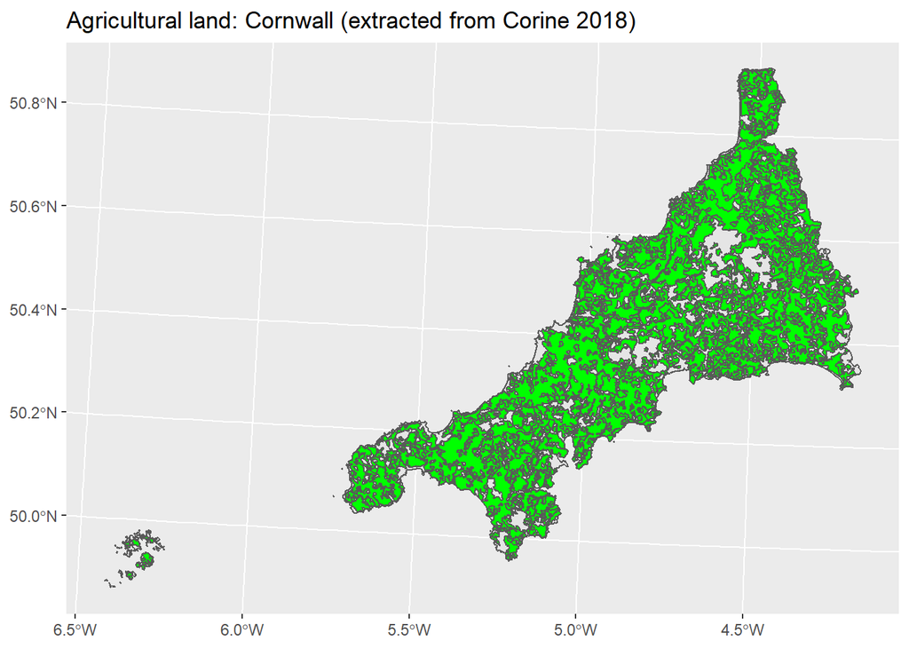

[output not shown]

```r
print(plot0)
```

```r
unlink(here("Out", "Tests", "Corine_Agri.shp"))
unlink(here("Out", "Tests", "Corine_Agri.dbf"))
unlink(here("Out", "Tests", "Corine_Agri.prj"))
unlink(here("Out", "Tests", "Corine_Agri.shx"))
st_write(corine.agri, here("Out", "Tests", "Corine_Agri.shp"))
```

### 1.3 P1 reduction calculations

With all the required input data in place, P1 reductions at county level can now be computed. A brief overview of the workflow:

- **Step 1**: Select the four target counties from the GB county data layer
- **Step 2**: Initiate a programming loop based on the counties (i.e. same code block is run for each county in turn)
- **Step 3**: Create a spatial layer of postcode districts that spatially intersect with the “active” county
- **Step 4**: Create a spatial layer of postcode districts clipped exactly to the extent of the “active” county
- **Step 5**: Create a spatial layer of postcode districts clipped exactly to the extent of the “active” county
- **Step 6**: Using the Corine data on agricultural land area (prepared in Section 1.2), calculate the agricultural land area totals for intersected postcode district polygons, and clipped postcode district polygons respectively. This gives us two values: 1) the total area of agricultural land in each postcode district, and; 2) the area of agricultural land in each postcode district that is *within* the active county
- **Step 7**: Using the agricultural land area proportions and the P1 reduction figures, calculate the “baseline” value for P1 in 2020 and following years with reductions applied up to and including 2027
- **Step 8**: Display output tables and bar plots
- **Step 9**: Export output tables and bar plots to CCRI shared drive

```
#> Subset, selecting only Cornwall (inc Isles of Scilly), Devon, Somerset, and Dorset
#> Create filter string (get names first!)
```

```r
counties <- c("Cornwall", "Devon", "Dorset", "Somerset")
# cornwall <- c("Cornwall")
```

```
#> Sequential integer counter (for figure numbers)
```

```r
i <-0
```

```
#> Initiate loop
```

```r
for(active_county in counties){
```

```
#> Loop counter (for table caption number)
```

```r
i <- i+1
```

```
#> Select target county (this will be start of loop)
```

```r
county <- counties.gb |>
  filter(NAME == active_county)
```

```
#> Select postcode district areas that intersect with active county polygon
```

```r
pcodes.int <- pcodes.gb[county,]
```

```
#> Add area (km2) column
```

```r
pcodes.int$AreaM2 <- st_area(pcodes.int)
```

```
#> Convert from m2 to km2
```

```r
pcodes.int$AREA_KM2_TOTAL <- pcodes.int$AreaM2 / 1000000
pcodes.int$AREA_KM2_TOTAL <- round(pcodes.int$AREA_KM2_TOTAL, digits = 3)
pcodes.int$AREA_KM2_TOTAL <- as.numeric(pcodes.int$AREA_KM2_TOTAL)
```

```
#> Export data for detailed visual checking in QGIS
#> Remove existing shapefile
```

```r
unlink(here("Out", "Tests", "pcodes.int.shp"))
unlink(here("Out", "Tests", "pcodes.int.dbf"))
unlink(here("Out", "Tests", "pcodes.int.prj"))
unlink(here("Out", "Tests", "pcodes.int.shx"))
st_write(pcodes.int, here("Out", "Tests", "pcodes.int.shp"), quiet = TRUE)
```

```
#> Generate a layer of clipped (cookie cutter) postcodes using active county boundary
```

```r
pcodes.clip <- st_intersection(pcodes.int, county)
```

```
#> Add area (km2) column
```

```r
pcodes.clip$AreaM2 <- st_area(pcodes.clip)
```

```
#> Convert from m2 to km2
```

```r
pcodes.clip$AREA_KM2_CLIP<- pcodes.clip$AreaM2 / 1000000
pcodes.clip$AREA_KM2_CLIP <- round(pcodes.clip$AREA_KM2_CLIP, digits = 3)
pcodes.clip$AREA_KM2_CLIP <- as.numeric(pcodes.clip$AREA_KM2_CLIP)
```

```
#> Export data for detailed visual checking in QGIS
#> Remove existing shapefile
```

```r
unlink(here("Out", "Tests", "pcodes.clip.shp"))
unlink(here("Out", "Tests", "pcodes.clip.dbf"))
unlink(here("Out", "Tests", "pcodes.clip.prj"))
unlink(here("Out", "Tests", "pcodes.clip.shx"))
st_write(pcodes.clip, here("Out", "Tests", "pcodes.clip.shp"), quiet = TRUE)
```

```
#> To calculate agri land differences for postcodes which straddle the boundary of target county...
#> 1. Intersect pcodes.int with corine.agri, to calculate area of agri land for all intersecting pcode district polys (whole polygon)
#> 2. Intersect pcodes.clip with corine.int to calculate area of agri land ony within target county polygon
#> 3. Calculate percentage difference between the TWO sets of area calculations to gove % of agri land in each pcode district polygon
```

```
#> 1. Intersect pcodes.int with corine.agri, to calculate area of agri land for all intersecting pcode district polys (whole polygon)
```

```r
agri.int.total <- st_intersection(pcodes.int, corine.agri)
```

```
#> Calculate area of Corine agri land
```

```r
agri.int.total$AREA_AGRI_TOTAL <- st_area(agri.int.total)
```

```
#> Convert from m2 to km2
```

```r
agri.int.total$AREA_AGRI_TOTAL <- agri.int.total$AREA_AGRI_TOTAL / 1000000
agri.int.total$AREA_AGRI_TOTAL <- round(agri.int.total$AREA_AGRI_TOTAL, digits = 3)
agri.int.total$AREA_AGRI_TOTAL <- as.numeric(agri.int.total$AREA_AGRI_TOTAL)
```

```
#> Export data for detailed visual checking in QGIS
#> Remove existing shapefile
```

```r
unlink(here("Out", "Tests", "agri.int.total.shp"))
unlink(here("Out", "Tests", "agri.int.total.dbf"))
unlink(here("Out", "Tests", "agri.int.total.prj"))
unlink(here("Out", "Tests", "agri.int.total.shx"))
st_write(agri.int.total, here("Out", "Tests", "agri.int.total.shp"), quiet = TRUE)
```

```
#> Create grouped (by pcode) non-geo version of the table
```

```r
st_geometry(agri.int.total) <- NULL
agri.int.total <- agri.int.total |>
  select(name, AREA_AGRI_TOTAL) |>
  group_by(name) |>
  summarise(AGRI_TOTAL = sum(AREA_AGRI_TOTAL))
```

```
#> 2. Intersect pcodes.clip with corine.int to calculate area of agri land ony within target county polygon
```

```r
agri.int.clip <- st_intersection(pcodes.clip, corine.agri)
```

```
#> Calculate area of Corine agri land
```

```r
agri.int.clip$AREA_AGRI_CLIP <- st_area(agri.int.clip)
```

```
#> Convert from m2 to km2
```

```r
agri.int.clip$AREA_AGRI_CLIP <- agri.int.clip$AREA_AGRI_CLIP / 1000000
agri.int.clip$AREA_AGRI_CLIP <- round(agri.int.clip$AREA_AGRI_CLIP, digits = 3)
agri.int.clip$AREA_AGRI_CLIP <- as.numeric(agri.int.clip$AREA_AGRI_CLIP)
```

```
#> Export data for detailed visual checking in QGIS
#> Remove existing shapefile
```

```r
unlink(here("Out", "Tests", "agri.int.clip.shp"))
unlink(here("Out", "Tests", "agri.int.clip.dbf"))
unlink(here("Out", "Tests", "agri.int.clip.prj"))
unlink(here("Out", "Tests", "agri.int.clip.shx"))
st_write(agri.int.clip, here("Out", "Tests", "agri.int.clip.shp"), quiet = TRUE)
```

```
#> Create grouped (by pcode) non-geo version of the table
```

```r
st_geometry(agri.int.clip) <- NULL
agri.int.clip <- agri.int.clip |>
  select(name, AREA_AGRI_CLIP) |>
  group_by(name) |>
  summarise(AGRI_CLIP = sum(AREA_AGRI_CLIP))
```

```
#> 3. Calculate percentage difference between the tow sets of area calculations to gove % of agri land in each pcode district polygon
#> Merge the two data frames to show size of agri area within and outside target county
```

```r
agri.merge <- merge(agri.int.total, agri.int.clip, by = "name", all.x = TRUE)
```

[output not shown]

```r
agri.merge$AGRI_TOTAL <- round(agri.merge$AGRI_TOTAL, digits = 3)
agri.merge$AGRI_CLIP <- round(agri.merge$AGRI_CLIP, digits = 2)
```

```
#> Calculate percentage of agri land within target county
```

```r
agri.merge$PCENT_AGRI_LAND <- agri.merge$AGRI_CLIP/ agri.merge$AGRI_TOTAL
```

```
#> Round up
```

```r
agri.merge$PCENT_AGRI_LAND <- round(agri.merge$PCENT_AGRI_LAND, digits = 3)
```

```
#> Extract postcode districts from the BPS source data ("db") which intersect with the active county polygon boundary
#> Do this via a merge between db and pcodes.int, keeping only matching records in a new data frame
#> Rename pcodes.in and drop geom
```

```r
pcodes.active <- pcodes.int
st_geometry(pcodes.active) <- NULL
BPS.merge <- merge(db, pcodes.active, by.x = "PostcodePrefix_F202B", "name", all.x = FALSE)
```

```
#> Convert all NAs to zeros in data frame
```

```r
BPS.merge[is.na(BPS.merge)] <- 0
```

```
#> BPS Calcs by year
```

```
#> 2020
#> Create table with baseline P1 (BPS + Greening) payments by postcode district for 2020 (no reductions applied)
```

```r
t1.2020 <- BPS.merge %>%
  group_by(PostcodePrefix_F202B) %>%
  summarise(P1_2020_Baseline = sum(`Basic payment scheme`) + sum(`Greening: practices beneficial for climate and environment`))
```

```
#> Check sum total of P1 for reference
```

```r
sum.original.p1 <- sum(t1.2020$P1_2020_Baseline)
```

```
#> Merge with agri.merge data frame to append 2020 calcs and create new master table "t1"
```

```r
t1 <- merge(t1.2020, agri.merge, by.x = "PostcodePrefix_F202B", by.y = "name")
```

```
#> #> Calculate P1 payment based on area of agri land within each postcode area
```

```r
t1$P1_2020 <- t1$P1_2020_Baseline * t1$PCENT_AGRI_LAND
```

```
#> Round to 2 decimal places
```

```r
t1$P1_2020 <- round(t1$P1_2020, digits = 2)
```

```
#> 2021
#> Need to work out reductions on a farm-by-farm basis, so need to return to original RPA data to calculate
```

```r
t1.2021 <- BPS.merge %>%
  select(PostcodePrefix_F202B, `Basic payment scheme`, `Greening: practices beneficial for climate and environment`)
```

```
#> Column to hold total total P1 payments (i.e. BPS + Greening) - baseline for 2020
```

```r
t1.2021$P1_2020 <- t1.2021$`Basic payment scheme` + t1.2021$`Greening: practices beneficial for climate and environment`
```

```
#> Add new column showing 2021 reductions
```

```r
t1.2021 <- t1.2021 %>%
  mutate(P1_2021 = case_when(P1_2020 <=30000 ~ P1_2020 * 0.95,
                              (P1_2020 >30000 & P1_2020 <=50000) ~ P1_2020 * 0.90,
                              (P1_2020 >50000 & P1_2020 <=150000) ~ P1_2020 * 0.80,
                              P1_2020 > 150000 ~ P1_2020 * 0.75))
# Group by postcode an summarise
t1.2021 <- t1.2021 %>%
  group_by(PostcodePrefix_F202B) %>%
  summarise(P1_2021 = sum(P1_2021))
```

```
#> Round
```

```r
t1.2021$P1_2021 <- round(t1.2021$P1_2021, digits = 2)
# merge with main P1 results table (m.)
t1 <- merge(t1, t1.2021, by.x = "PostcodePrefix_F202B", by.y = "PostcodePrefix_F202B", all.x = TRUE)
# Change values according to agi land area proportion
t1$P1_2021 <- t1$P1_2021 * t1$PCENT_AGRI_LAND #> Round
t1$P1_2021 <- round(t1$P1_2021, digits = 2)
```

```
#> Check sum
```

```r
sum.p1.2021 <- sum(t1$P1_2021)
```

```
#> 2022
#> Need to work out reductions on a farm-by-farm basis, so need to return to original RPA data to calculate
```

```r
t1.2022 <- BPS.merge %>%
  select(PostcodePrefix_F202B, `Basic payment scheme`, `Greening: practices beneficial for climate and environment`)
```

```
#> Column to hold total total P1 payments (i.e. BPS + Greening) - baseline for 2020
```

```r
t1.2022$P1_2020 <- t1.2022$`Basic payment scheme` + t1.2022$`Greening: practices beneficial for climate and environment`
```

```
#> Add new column showing 2022 reductions
```

```r
t1.2022 <- t1.2022 %>%
   mutate(P1_2022 = case_when(P1_2020<=30000 ~ P1_2020* 0.80,
                             (P1_2020>30000 & P1_2020<=50000) ~ P1_2020* 0.75,
                             (P1_2020>50000 & P1_2020<=150000) ~ P1_2020* 0.65,
                             P1_2020> 150000 ~ P1_2020* 0.60))
# Group by postcode an summarise
t1.2022 <- t1.2022 %>%
  group_by(PostcodePrefix_F202B) %>%
  summarise(P1_2022 = sum(P1_2022))
```

```
#> Round
```

```r
t1.2022$P1_2022 <- round(t1.2022$P1_2022, digits = 2)
# merge with main P1 results table (m.)
t1 <- merge(t1, t1.2022, by.x = "PostcodePrefix_F202B", by.y = "PostcodePrefix_F202B", all.x = TRUE)
# Change values according to agi land area proportion
t1$P1_2022 <- t1$P1_2022 * t1$PCENT_AGRI_LAND #> Round
t1$P1_2022 <- round(t1$P1_2022, digits = 2)
```

```
#> Check sum
```

```r
sum.p1.2022 <- sum(t1$P1_2022)
```

```
#> 2023
#> Need to work out reductions on a farm-by-farm basis, so need to return to original RPA data to calculate
```

```r
t1.2023 <- BPS.merge %>%
  select(PostcodePrefix_F202B, `Basic payment scheme`, `Greening: practices beneficial for climate and environment`)
```

```
#> Column to hold total total P1 payments (i.e. BPS + Greening) - baseline for 2020
```

```r
t1.2023$P1_2020 <- t1.2023$`Basic payment scheme` + t1.2023$`Greening: practices beneficial for climate and environment`
```

```
#> Add new column showing 2023 reductions
```

```r
t1.2023 <- t1.2023 %>%
  mutate(P1_2023 = case_when(P1_2020 <=30000 ~ P1_2020 * 0.65,
                             (P1_2020 >30000 & P1_2020 <=50000) ~ P1_2020 * 0.60,
                             (P1_2020 >50000 & P1_2020 <=150000) ~ P1_2020 * 0.50,
                             P1_2020 > 150000 ~ P1_2020 * 0.45))
# Group by postcode an summarise
t1.2023 <- t1.2023 %>%
  group_by(PostcodePrefix_F202B) %>%
  summarise(P1_2023 = sum(P1_2023))
```

```
#> Round
```

```r
t1.2023$P1_2023 <- round(t1.2023$P1_2023, digits = 2)
# merge with main P1 results table (m.)
t1 <- merge(t1, t1.2023, by.x = "PostcodePrefix_F202B", by.y = "PostcodePrefix_F202B", all.x = TRUE)
# Change values according to agi land area proportion
t1$P1_2023 <- t1$P1_2023 * t1$PCENT_AGRI_LAND #> Round
t1$P1_2023 <- round(t1$P1_2023, digits = 2)
```

```
#> Check sum
```

```r
sum.p1.2023 <- sum(t1$P1_2023)
```

```
#> 2024
#> Need to work out reductions on a farm-by-farm basis, so need to return to original RPA data to calculate
```

```r
t1.2024 <- BPS.merge %>%
  select(PostcodePrefix_F202B, `Basic payment scheme`, `Greening: practices beneficial for climate and environment`)
```

```
#> Column to hold total total P1 payments (i.e. BPS + Greening) - baseline for 2020
```

```r
t1.2024$P1_2020 <- t1.2024$`Basic payment scheme` + t1.2024$`Greening: practices beneficial for climate and environment`
```

```
#> Add new column showing 2024 reductions
```

```r
t1.2024 <- t1.2024 %>%
  mutate(P1_2024 = case_when(P1_2020 <=30000 ~ P1_2020 * 0.50,
                             (P1_2020 >30000 & P1_2020 <=50000) ~ P1_2020 * 0.45,
                             (P1_2020 >50000 & P1_2020 <=150000) ~ P1_2020 * 0.35,
                             P1_2020 > 150000 ~ P1_2020 * 0.30))
# Group by postcode an summarise
t1.2024 <- t1.2024 %>%
  group_by(PostcodePrefix_F202B) %>%
  summarise(P1_2024 = sum(P1_2024))
```

```
#> Round
```

```r
t1.2024$P1_2024 <- round(t1.2024$P1_2024, digits = 2)
# merge with main P1 results table (m.)
t1 <- merge(t1, t1.2024, by.x = "PostcodePrefix_F202B", by.y = "PostcodePrefix_F202B", all.x = TRUE)
# Change values according to agi land area proportion
t1$P1_2024 <- t1$P1_2024 * t1$PCENT_AGRI_LAND #> Round
t1$P1_2024 <- round(t1$P1_2024, digits = 2)
```

```
#> Check sum
```

```r
sum.p1.2024 <- sum(t1$P1_2024)
```

```
#> 2025
#> Need to work out reductions on a farm-by-farm basis, so need to return to original RPA data to calculate
```

```r
t1.2025 <- BPS.merge %>%
  select(PostcodePrefix_F202B, `Basic payment scheme`, `Greening: practices beneficial for climate and environment`)
```

```
#> Column to hold total total P1 payments (i.e. BPS + Greening) - baseline for 2020
```

```r
t1.2025$P1_2020 <- t1.2025$`Basic payment scheme` + t1.2025$`Greening: practices beneficial for climate and environment`
```

```
#> Add new column showing 2025 reductions
```

```r
t1.2025 <- t1.2025 %>%
 mutate(P1_2025 = case_when(P1_2020 <=30000 ~ P1_2020 * 0.40,
                             (P1_2020 >30000 & P1_2020 <=50000) ~ P1_2020 * 0.35,
                             (P1_2020 >50000 & P1_2020 <=150000) ~ P1_2020 * 0.25,
                             P1_2020 > 150000 ~ P1_2020 * 0.20))
# Group by postcode an summarise
t1.2025 <- t1.2025 %>%
  group_by(PostcodePrefix_F202B) %>%
  summarise(P1_2025 = sum(P1_2025))
```

```
#> Round
```

```r
t1.2025$P1_2025 <- round(t1.2025$P1_2025, digits = 2)
# merge with main P1 results table (m.)
t1 <- merge(t1, t1.2025, by.x = "PostcodePrefix_F202B", by.y = "PostcodePrefix_F202B", all.x = TRUE)
# Change values according to agi land area proportion
t1$P1_2025 <- t1$P1_2025 * t1$PCENT_AGRI_LAND #> Round
t1$P1_2025 <- round(t1$P1_2025, digits = 2)
```

```
#> Check sum
```

```r
sum.p1.2025 <- sum(t1$P1_2025)
```

```
#> 2026
#> Need to work out reductions on a farm-by-farm basis, so need to return to original RPA data to calculate
```

```r
t1.2026 <- BPS.merge %>%
  select(PostcodePrefix_F202B, `Basic payment scheme`, `Greening: practices beneficial for climate and environment`)
```

```
#> Column to hold total total P1 payments (i.e. BPS + Greening) - baseline for 2020
```

```r
t1.2026$P1_2020 <- t1.2026$`Basic payment scheme` + t1.2026$`Greening: practices beneficial for climate and environment`
```

```
#> Add new column showing 2026 reductions
```

```r
t1.2026 <- t1.2026 %>%
  mutate(P1_2026 = case_when(P1_2020 <=30000 ~ P1_2020 * 0.25,
                             (P1_2020 >30000 & P1_2020 <=50000) ~ P1_2020 * 0.25,
                             (P1_2020 >50000 & P1_2020 <=150000) ~ P1_2020 * 0.15,
                             P1_2020 > 150000 ~ P1_2020 * 0.15))
# Group by postcode an summarise
t1.2026 <- t1.2026 %>%
  group_by(PostcodePrefix_F202B) %>%
  summarise(P1_2026 = sum(P1_2026))
```

```
#> Round
```

```r
t1.2026$P1_2026 <- round(t1.2026$P1_2026, digits = 2)
# merge with main P1 results table (m.)
t1 <- merge(t1, t1.2026, by.x = "PostcodePrefix_F202B", by.y = "PostcodePrefix_F202B", all.x = TRUE)
# Change values according to agi land area proportion
t1$P1_2026 <- t1$P1_2026 * t1$PCENT_AGRI_LAND #> Round
t1$P1_2026 <- round(t1$P1_2026, digits = 2)
```

```
#> Check sum
```

```r
sum.p1.2026 <- sum(t1$P1_2026)
```

```
#> 2027
#> Need to work out reductions on a farm-by-farm basis, so need to return to original RPA data to calculate
```

```r
t1.2027 <- BPS.merge %>%
  select(PostcodePrefix_F202B, `Basic payment scheme`, `Greening: practices beneficial for climate and environment`)
```

```
#> Column to hold total total P1 payments (i.e. BPS + Greening) - baseline for 2020
```

```r
t1.2027$P1_2020 <- t1.2027$`Basic payment scheme` + t1.2027$`Greening: practices beneficial for climate and environment`
```

```
#> Add new column showing 2027 reductions
```

```r
t1.2027 <- t1.2027 %>%
   mutate(P1_2027 = case_when(P1_2020<=30000 ~ P1_2020* 0.15,
                             (P1_2020>30000 & P1_2020<=50000) ~ P1_2020* 0.15,
                             (P1_2020>50000 & P1_2020<=150000) ~ P1_2020* 0.10,
                             P1_2020> 150000 ~ P1_2020* 0.10))
# Group by postcode an summarise
t1.2027 <- t1.2027 %>%
  group_by(PostcodePrefix_F202B) %>%
  summarise(P1_2027 = sum(P1_2027))
```

```
#> Round
```

```r
t1.2027$P1_2027 <- round(t1.2027$P1_2027, digits = 2)
# merge with main P1 results table (m.)
t1 <- merge(t1, t1.2027, by.x = "PostcodePrefix_F202B", by.y = "PostcodePrefix_F202B", all.x = TRUE)
# Change values according to agi land area proportion
t1$P1_2027 <- t1$P1_2027 * t1$PCENT_AGRI_LAND #> Round
t1$P1_2027 <- round(t1$P1_2027, digits = 2)
```

```
#> Check sum
```

```r
sum.p1.2027 <- sum(t1$P1_2027)
```

```
#> Convert all NAs to zeros in data frame
```

```r
t1[is.na(t1)] <- 0
```

```
#> Create plot
```

```
#> P1 payments by year
```

```r
p1.in <- as.data.frame(colSums(t1[6:13]))
```

```
#> Change rownames to column "Value"
```

```r
p1.plot <- tibble::rownames_to_column(p1.in, "VALUE")
```

```
#> Extract year from string
```

```r
p1.plot$VALUE <- sub("^.*([0-9]{4}).*", "\\1", p1.plot$VALUE)
names(p1.plot)[1]<-paste("Year")
names(p1.plot)[2]<-paste("Value_bps")
```

```
#> Print table t1 on web page
```

```r
print(knitr::kable(t1, col.names = c("PC", "2020_Unadjusted", "Agri_In", "Agri_Out", "Agri_PC", "2020", "2021", "2022", "2023", "2024", "2025", "2026", "2027"), caption = paste0("Table 1.", i , " ", "P1 reductions by postcode district - ",  active_county)))
```

```
#> Add line breaks
```

```r
cat("\n")
cat("\n")
cat("\n")
cat("\n")
cat("\n")
cat("\n")


# Simple bar chart
plot1 <- ggplot(p1.plot, aes(x=Year, y=Value_bps)) +
  theme_bw() +
  geom_bar(stat = "identity", fill="#2c66b8", width = 0.6) +
  geom_text(aes(label= paste0(round(Value_bps / 1000000, digits = 1), " M")), vjust = 1.5, colour = "white") +
  labs(title = paste0("Pillar 1 reductions:", " ", active_county), x = "Year", y = "Value (£)") +
  theme(plot.title = element_text(hjust = 0.5)) +
  theme(axis.title.y = element_text(margin = margin(t = 0, r = 16, b = 0, l = 0))) +
  theme(axis.title.x = element_text(margin = margin(t = 12, r = 0, b = 0, l = 0))) +
  theme(legend.position="none") +
  scale_y_continuous(labels = scales::unit_format(unit = "M", scale = 1e-6))
plot1
```

```
#> Add line breaks
```

```r
cat("\n")
cat("\n")
cat("\n")
cat("\n")
cat("\n")
cat("\n")
```

```
#> Render on web page
```

```r
print(plot1)
```

```
#> Export the plot
```

```r
ggsave(here("Out", "P1", "County", "Plot", paste0("P1_Reductions_", active_county, ".png")))
```

```
#> Export final t1 table
```

```r
write_csv(t1, here("Out", "P1", "County", "CSV", paste0("P1_Reductions_", active_county, ".csv")))

}
```

Table 1.1 P1 reductions by postcode district - Cornwall

| PC | 2020_Unadjusted | Agri_In | Agri_Out | Agri_PC | 2020 | 2021 | 2022 | 2023 | 2024 | 2025 | 2026 | 2027 |
| --- | --- | --- | --- | --- | --- | --- | --- | --- | --- | --- | --- | --- |
| EX22 | 5669306.76 | 309.280 | 60.04 | 0.194 | 1099845.51 | 1009289.94 | 844313.11 | 679336.28 | 514359.46 | 404374.90 | 259384.85 | 157188.56 |
| EX23 | 2746120.50 | 161.015 | 155.91 | 0.968 | 2658244.64 | 2452387.98 | 2053651.28 | 1654914.59 | 1256177.89 | 990353.42 | 636404.35 | 384658.29 |
| EX39 | 4543093.48 | 217.013 | 0.11 | 0.001 | 4543.09 | 4080.62 | 3399.16 | 2717.70 | 2036.23 | 1581.92 | 1017.41 | 622.28 |
| PL10 | 189625.56 | 9.333 | 9.33 | 1.000 | 189625.56 | 161357.89 | 132914.06 | 104470.22 | 76026.39 | 57063.83 | 34882.13 | 22181.70 |
| PL11 | 693638.88 | 31.060 | 31.06 | 1.000 | 693638.88 | 590828.92 | 486783.08 | 382737.25 | 278691.42 | 209327.53 | 140836.52 | 87759.23 |
| PL12 | 1606968.13 | 97.248 | 96.39 | 0.991 | 1592505.42 | 1434640.46 | 1195764.66 | 956888.85 | 718013.04 | 558762.49 | 356392.72 | 218008.99 |
| PL13 | 1346066.02 | 68.542 | 68.54 | 1.000 | 1346066.02 | 1224847.81 | 1022937.90 | 821028.00 | 619118.10 | 484511.50 | 317521.23 | 192412.27 |
| PL14 | 3699213.10 | 199.621 | 199.62 | 1.000 | 3699213.10 | 3360619.05 | 2805737.08 | 2250855.12 | 1695973.15 | 1326051.84 | 855607.66 | 520284.16 |
| PL15 | 6365797.99 | 323.655 | 289.60 | 0.895 | 5697389.20 | 5190495.79 | 4335887.41 | 3481279.03 | 2626670.65 | 2056931.73 | 1328062.41 | 806465.94 |
| PL16 | 777462.94 | 51.306 | 0.40 | 0.008 | 6219.70 | 5753.88 | 4820.93 | 3887.97 | 2955.02 | 2333.05 | 1514.73 | 912.86 |
| PL17 | 1330900.25 | 82.452 | 81.32 | 0.986 | 1312267.65 | 1204492.63 | 1007652.48 | 810812.33 | 613972.18 | 482745.42 | 311422.91 | 188518.15 |
| PL18 | 149813.87 | 10.966 | 9.86 | 0.899 | 134682.67 | 127948.54 | 107746.14 | 87543.74 | 67341.34 | 53873.07 | 33670.67 | 20202.40 |
| PL19 | 2872716.90 | 143.412 | 1.02 | 0.007 | 20109.02 | 17907.29 | 14890.94 | 11874.58 | 8858.23 | 6847.33 | 4376.04 | 2690.74 |
| PL20 | 2201678.08 | 164.444 | 0.82 | 0.005 | 11008.39 | 9555.35 | 7904.09 | 6252.83 | 4601.57 | 3500.73 | 2241.09 | 1395.76 |
| PL22 | 1066944.05 | 51.502 | 51.50 | 1.000 | 1066944.05 | 975915.67 | 815874.06 | 655832.45 | 495790.85 | 389096.44 | 256291.14 | 154819.17 |
| PL23 | 342779.53 | 18.717 | 18.71 | 1.000 | 342779.53 | 299483.04 | 248066.11 | 196649.18 | 145232.25 | 110954.30 | 71527.08 | 44333.03 |
| PL24 | 295252.56 | 22.745 | 22.72 | 0.999 | 294957.31 | 278472.22 | 234228.63 | 189985.02 | 145741.43 | 116245.70 | 73739.33 | 44243.59 |
| PL25 | 102286.28 | 8.790 | 8.79 | 1.000 | 102286.28 | 97171.97 | 81829.02 | 66486.08 | 51143.14 | 40914.51 | 25571.57 | 15342.94 |
| PL26 | 2117478.59 | 109.572 | 109.55 | 1.000 | 2117478.59 | 1866270.68 | 1548648.89 | 1231027.11 | 913405.32 | 701657.46 | 441685.54 | 273779.74 |
| PL27 | 2006347.61 | 104.429 | 104.40 | 1.000 | 2006347.61 | 1794473.10 | 1493520.96 | 1192568.82 | 891616.67 | 690981.91 | 442622.89 | 271470.14 |
| PL28 | 395589.12 | 27.003 | 26.96 | 0.998 | 394797.94 | 357752.54 | 298532.86 | 239313.16 | 180093.47 | 140613.68 | 88187.79 | 53963.85 |
| PL29 | 418500.38 | 17.702 | 17.67 | 0.998 | 417663.38 | 365148.36 | 302498.85 | 239849.34 | 177199.83 | 135433.50 | 84359.76 | 52621.47 |
| PL30 | 4225344.65 | 216.220 | 216.21 | 1.000 | 4225344.65 | 3774675.54 | 3140873.85 | 2507072.15 | 1873270.45 | 1450735.99 | 921158.70 | 566212.97 |
| PL31 | 123129.98 | 8.036 | 8.04 | 1.000 | 123129.98 | 114872.48 | 96402.98 | 77933.49 | 59463.99 | 47150.99 | 30782.50 | 18469.50 |
| PL32 | 1462284.16 | 77.982 | 77.98 | 1.000 | 1462284.16 | 1289920.03 | 1070577.40 | 851234.78 | 631892.15 | 485663.74 | 309257.44 | 191185.82 |
| PL33 | 367946.45 | 16.134 | 16.13 | 1.000 | 367946.45 | 341738.88 | 286546.91 | 231354.94 | 176162.98 | 139368.33 | 91986.61 | 55191.97 |
| PL34 | 194194.17 | 13.036 | 13.03 | 1.000 | 194194.17 | 173971.89 | 144842.76 | 115713.64 | 86584.51 | 67165.09 | 41540.16 | 25624.93 |
| PL35 | 405298.48 | 24.497 | 24.48 | 0.999 | 404893.18 | 379023.00 | 318289.02 | 257555.05 | 196821.07 | 156331.75 | 101223.30 | 60733.98 |
| PL5 | 115480.60 | 6.203 | 0.00 | 0.000 | 0.00 | 0.00 | 0.00 | 0.00 | 0.00 | 0.00 | 0.00 | 0.00 |
| TR1 | 150767.81 | 10.057 | 10.06 | 1.000 | 150767.81 | 141036.09 | 118420.92 | 95805.75 | 73190.58 | 58113.80 | 37691.95 | 22615.17 |
| TR10 | 242695.35 | 22.429 | 22.43 | 1.000 | 242695.35 | 227005.59 | 190601.29 | 154196.98 | 117792.68 | 93523.15 | 60673.84 | 36404.30 |
| TR11 | 809918.04 | 47.771 | 47.76 | 1.000 | 809918.04 | 739935.50 | 618447.79 | 496960.08 | 375472.38 | 294480.57 | 190239.64 | 115367.77 |
| TR12 | 2347108.17 | 120.207 | 120.11 | 0.999 | 2344761.06 | 2114143.59 | 1762429.43 | 1410715.27 | 1059001.11 | 824525.00 | 527904.35 | 322571.20 |
| TR13 | 1529143.44 | 76.348 | 76.33 | 1.000 | 1529143.44 | 1363864.31 | 1134492.79 | 905121.28 | 675749.76 | 522835.42 | 333307.45 | 204882.31 |
| TR14 | 570914.31 | 52.237 | 52.24 | 1.000 | 570914.31 | 534880.93 | 449243.79 | 363606.64 | 277969.50 | 220878.06 | 142728.58 | 85637.15 |
| TR15 | 52472.02 | 5.335 | 5.34 | 1.001 | 52524.49 | 49898.27 | 42019.60 | 34140.92 | 26262.25 | 21009.80 | 13131.13 | 7878.67 |
| TR16 | 562427.41 | 57.361 | 57.35 | 1.000 | 562427.41 | 517473.13 | 433109.02 | 348744.91 | 264380.80 | 208138.06 | 129384.91 | 78753.14 |
| TR17 | 31789.87 | 3.792 | 3.79 | 0.999 | 31758.08 | 30170.18 | 25406.47 | 20642.76 | 15879.04 | 12703.23 | 7939.52 | 4763.71 |
| TR18 | 43280.41 | 2.995 | 3.00 | 1.002 | 43366.97 | 41198.62 | 34693.58 | 28188.53 | 21683.48 | 17346.78 | 10841.74 | 6505.04 |
| TR19 | 1255959.76 | 72.809 | 72.79 | 1.000 | 1255959.76 | 1134828.39 | 946434.43 | 758040.46 | 569646.50 | 444050.52 | 282318.39 | 172558.19 |
| TR2 | 3014939.68 | 158.572 | 158.50 | 1.000 | 3014939.68 | 2674622.68 | 2222381.73 | 1770140.77 | 1317899.82 | 1016405.85 | 650596.61 | 400671.80 |
| TR20 | 1844232.47 | 87.139 | 87.13 | 1.000 | 1844232.47 | 1655324.13 | 1378689.26 | 1102054.39 | 825419.52 | 640996.27 | 401884.76 | 247048.19 |
| TR21 | 112278.57 | 5.625 | 5.60 | 0.996 | 111829.46 | 97562.55 | 80788.14 | 64013.72 | 47239.30 | 36056.36 | 22173.75 | 13882.61 |
| TR22 | 2863.23 | 1.112 | 1.10 | 0.989 | 2831.73 | 2690.15 | 2265.38 | 1840.63 | 1415.87 | 1132.69 | 707.94 | 424.76 |
| TR23 | 0.00 | 0.833 | 0.83 | 0.996 | 0.00 | 0.00 | 0.00 | 0.00 | 0.00 | 0.00 | 0.00 | 0.00 |
| TR24 | 15758.29 | 1.495 | 1.49 | 0.997 | 15711.02 | 14925.47 | 12568.81 | 10212.16 | 7855.51 | 6284.41 | 3927.75 | 2356.65 |
| TR25 | 12436.24 | 1.701 | 1.69 | 0.994 | 12361.62 | 11743.54 | 9889.30 | 8035.06 | 6180.81 | 4944.65 | 3090.41 | 1854.25 |
| TR26 | 509676.37 | 20.354 | 20.35 | 1.000 | 509676.37 | 462832.82 | 386381.37 | 309929.91 | 233478.46 | 182510.82 | 119703.95 | 72593.89 |
| TR27 | 1128696.86 | 56.978 | 56.97 | 1.000 | 1128696.86 | 993178.89 | 823874.36 | 654569.83 | 485265.30 | 372395.61 | 235024.62 | 145729.73 |
| TR3 | 777745.65 | 48.742 | 48.73 | 1.000 | 777745.65 | 703902.64 | 587240.79 | 470578.94 | 353917.10 | 276142.53 | 174426.84 | 106657.06 |
| TR4 | 1695773.01 | 106.658 | 106.66 | 1.000 | 1695773.01 | 1533393.78 | 1279027.83 | 1024661.87 | 770295.92 | 600718.62 | 385095.57 | 234942.11 |
| TR5 | 146924.33 | 12.335 | 12.33 | 1.000 | 146924.33 | 137698.29 | 115659.64 | 93620.99 | 71582.34 | 56889.91 | 36731.08 | 22038.65 |
| TR6 | 114737.04 | 5.302 | 5.30 | 1.000 | 114737.04 | 101498.14 | 84287.59 | 67077.03 | 49866.48 | 38392.77 | 23682.90 | 14709.87 |
| TR7 | 0.00 | 2.474 | 2.47 | 0.998 | 0.00 | 0.00 | 0.00 | 0.00 | 0.00 | 0.00 | 0.00 | 0.00 |
| TR8 | 1918497.42 | 119.637 | 119.62 | 1.000 | 1918497.42 | 1702684.63 | 1414910.01 | 1127135.40 | 839360.79 | 647511.05 | 415615.20 | 255770.04 |
| TR9 | 654565.36 | 39.651 | 39.65 | 1.000 | 654565.36 | 595145.15 | 496960.35 | 398775.54 | 300590.74 | 235134.20 | 149961.52 | 91344.89 |

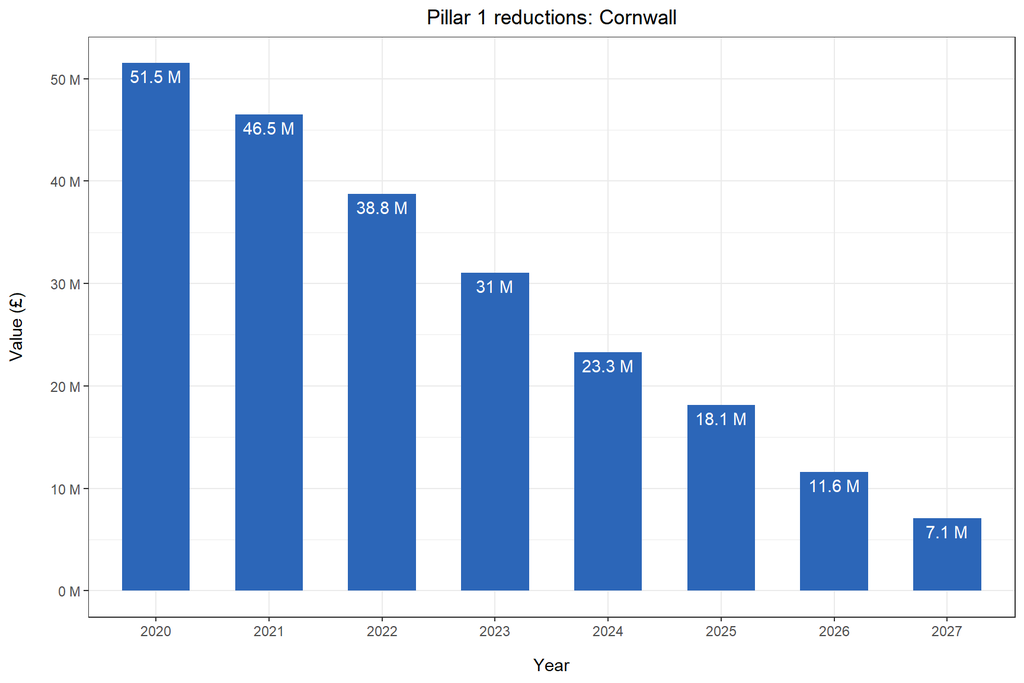

Table 1.2 P1 reductions by postcode district - Devon

| PC | 2020_Unadjusted | Agri_In | Agri_Out | Agri_PC | 2020 | 2021 | 2022 | 2023 | 2024 | 2025 | 2026 | 2027 |
| --- | --- | --- | --- | --- | --- | --- | --- | --- | --- | --- | --- | --- |
| DT6 | 3036994.48 | 158.966 | 0.36 | 0.002 | 6073.99 | 5382.63 | 4471.53 | 3560.43 | 2649.33 | 2041.93 | 1292.80 | 798.25 |
| DT7 | 238968.44 | 16.753 | 15.32 | 0.914 | 218417.15 | 192242.36 | 159479.78 | 126717.21 | 93954.64 | 72112.92 | 45741.86 | 28331.36 |
| EX1 | 194693.43 | 3.023 | 3.02 | 0.999 | 194498.74 | 183115.46 | 153940.65 | 124765.84 | 95591.03 | 76141.15 | 48624.69 | 29174.81 |
| EX10 | 988503.32 | 52.203 | 52.20 | 1.000 | 988503.32 | 865341.81 | 717066.31 | 568790.81 | 420515.32 | 321664.98 | 211756.34 | 130590.75 |
| EX11 | 515375.44 | 33.269 | 33.27 | 1.000 | 515375.44 | 464148.89 | 386842.58 | 309536.26 | 232229.94 | 180692.40 | 117277.18 | 71522.98 |
| EX12 | 475378.22 | 24.567 | 24.56 | 1.000 | 475378.22 | 413573.15 | 342266.42 | 270959.68 | 199652.95 | 152115.13 | 97410.08 | 60589.49 |
| EX13 | 2276377.07 | 111.911 | 107.43 | 0.960 | 2185321.99 | 2017742.73 | 1689944.43 | 1362146.13 | 1034347.83 | 815815.63 | 521702.15 | 315484.13 |
| EX14 | 3584346.54 | 186.890 | 186.13 | 0.996 | 3570009.15 | 3288289.19 | 2752787.82 | 2217286.45 | 1681785.07 | 1324784.15 | 841566.24 | 510033.34 |
| EX15 | 3044385.84 | 167.143 | 166.04 | 0.993 | 3023075.14 | 2826972.53 | 2373511.26 | 1920049.99 | 1466588.72 | 1164281.21 | 750243.74 | 450698.75 |
| EX16 | 6005179.21 | 325.694 | 322.95 | 0.992 | 5957137.78 | 5548811.89 | 4655241.22 | 3761670.55 | 2868099.88 | 2272386.11 | 1443349.96 | 870603.42 |
| EX17 | 5886022.85 | 293.242 | 293.24 | 1.000 | 5886022.85 | 5295893.63 | 4412990.20 | 3530086.78 | 2647183.35 | 2058581.06 | 1315300.89 | 804801.02 |
| EX18 | 1746019.28 | 103.597 | 103.60 | 1.000 | 1746019.28 | 1618154.73 | 1356251.84 | 1094348.95 | 832446.06 | 657844.13 | 422280.55 | 254790.76 |
| EX19 | 1737511.41 | 94.687 | 94.69 | 1.000 | 1737511.41 | 1624901.40 | 1364274.69 | 1103647.98 | 843021.27 | 669270.13 | 427002.09 | 256938.83 |
| EX2 | 573837.75 | 19.150 | 19.15 | 1.000 | 573837.75 | 495976.30 | 409900.64 | 323824.98 | 237749.31 | 180365.54 | 112993.93 | 70842.91 |
| EX20 | 7462904.40 | 389.425 | 389.42 | 1.000 | 7462904.40 | 6763333.19 | 5643897.53 | 4524461.87 | 3405026.21 | 2658735.77 | 1685950.37 | 1029547.80 |
| EX21 | 2399858.70 | 145.033 | 145.03 | 1.000 | 2399858.70 | 2236945.26 | 1876966.45 | 1516987.65 | 1157008.84 | 917022.97 | 583169.41 | 351581.17 |
| EX22 | 5669306.76 | 309.280 | 249.23 | 0.806 | 4569461.25 | 4193235.50 | 3507816.32 | 2822397.13 | 2136977.94 | 1680031.82 | 1077650.46 | 653061.77 |
| EX23 | 2746120.50 | 161.015 | 5.11 | 0.032 | 87875.86 | 81070.68 | 67889.30 | 54707.92 | 41526.54 | 32738.96 | 21038.16 | 12715.98 |
| EX24 | 781691.86 | 44.070 | 44.07 | 1.000 | 781691.86 | 728370.10 | 611116.32 | 493862.54 | 376608.76 | 298439.57 | 190347.70 | 114716.14 |
| EX3 | 116221.08 | 7.142 | 7.14 | 1.000 | 116221.08 | 108799.55 | 91366.39 | 73933.23 | 56500.06 | 44877.96 | 29055.27 | 17433.16 |
| EX31 | 4437568.50 | 215.235 | 215.23 | 1.000 | 4437568.50 | 4001220.85 | 3335585.57 | 2669950.30 | 2004315.02 | 1560558.17 | 1002774.60 | 612326.51 |
| EX32 | 2503991.07 | 115.188 | 115.19 | 1.000 | 2503991.07 | 2258849.75 | 1883251.09 | 1507652.43 | 1132053.77 | 881654.66 | 562531.22 | 343865.39 |
| EX33 | 721810.94 | 43.430 | 43.43 | 1.000 | 721810.94 | 643023.10 | 534751.46 | 426479.82 | 318208.18 | 246027.08 | 157286.94 | 96688.75 |
| EX34 | 1182067.84 | 69.853 | 69.85 | 1.000 | 1182067.84 | 1094341.86 | 917031.69 | 739721.51 | 562411.34 | 444204.55 | 287578.34 | 173340.86 |
| EX35 | 653966.01 | 54.251 | 45.86 | 0.845 | 552601.28 | 485439.83 | 402549.64 | 319659.44 | 236769.25 | 181509.13 | 114058.81 | 70844.44 |
| EX36 | 4654512.01 | 226.749 | 216.85 | 0.956 | 4449713.48 | 4023360.26 | 3355903.24 | 2688446.22 | 2020989.20 | 1576017.85 | 1007128.87 | 614807.27 |
| EX37 | 2107604.22 | 115.910 | 115.91 | 1.000 | 2107604.22 | 1961614.56 | 1645473.93 | 1329333.30 | 1013192.67 | 802432.24 | 519266.49 | 312323.35 |
| EX38 | 1772073.96 | 93.861 | 93.86 | 1.000 | 1772073.96 | 1641940.91 | 1376129.82 | 1110318.72 | 844507.63 | 667300.23 | 426286.32 | 257445.01 |
| EX39 | 4543093.48 | 217.013 | 216.85 | 0.999 | 4538550.39 | 4076543.31 | 3395760.75 | 2714978.18 | 2034195.63 | 1580340.59 | 1016395.50 | 621661.51 |
| EX4 | 345514.09 | 33.458 | 33.46 | 1.000 | 345514.09 | 328238.39 | 276411.27 | 224584.16 | 172757.05 | 138205.64 | 86378.52 | 51827.11 |
| EX5 | 3671497.74 | 204.035 | 204.04 | 1.000 | 3671497.74 | 3249242.29 | 2698517.62 | 2147792.96 | 1597068.30 | 1229918.53 | 776091.33 | 479833.11 |
| EX6 | 2976600.96 | 172.906 | 172.91 | 1.000 | 2976600.96 | 2677064.48 | 2230574.33 | 1784084.19 | 1337594.04 | 1039933.95 | 674592.36 | 411711.21 |
| EX7 | 246386.69 | 15.807 | 15.81 | 1.000 | 246386.69 | 234067.36 | 197109.35 | 160151.35 | 123193.34 | 98554.68 | 61596.67 | 36958.00 |
| EX8 | 160334.56 | 12.720 | 12.72 | 1.000 | 160334.56 | 148533.85 | 124483.67 | 100433.48 | 76383.30 | 60349.84 | 40083.64 | 24050.18 |
| EX9 | 735024.20 | 18.624 | 18.61 | 0.999 | 734289.18 | 599222.77 | 489079.39 | 378936.01 | 268792.64 | 195363.72 | 133032.00 | 84873.23 |
| PL10 | 189625.56 | 9.333 | 0.00 | 0.000 | 0.00 | 0.00 | 0.00 | 0.00 | 0.00 | 0.00 | 0.00 | 0.00 |
| PL12 | 1606968.13 | 97.248 | 0.86 | 0.009 | 14462.71 | 13029.03 | 10859.62 | 8690.21 | 6520.80 | 5074.53 | 3236.66 | 1979.90 |
| PL15 | 6365797.99 | 323.655 | 34.06 | 0.105 | 668408.79 | 608940.85 | 508679.53 | 408418.21 | 308156.89 | 241316.01 | 155806.20 | 94613.32 |
| PL16 | 777462.94 | 51.306 | 50.91 | 0.992 | 771243.24 | 713481.59 | 597795.10 | 482108.61 | 366422.12 | 289297.80 | 187827.07 | 113194.62 |
| PL17 | 1330900.25 | 82.452 | 1.13 | 0.014 | 18632.60 | 17102.33 | 14307.44 | 11512.55 | 8717.66 | 6854.40 | 4421.83 | 2676.73 |
| PL18 | 149813.87 | 10.966 | 1.10 | 0.100 | 14981.39 | 14232.32 | 11985.11 | 9737.90 | 7490.69 | 5992.56 | 3745.35 | 2247.21 |
| PL19 | 2872716.90 | 143.412 | 142.39 | 0.993 | 2852607.88 | 2540276.71 | 2112385.53 | 1684494.35 | 1256603.17 | 971342.38 | 620771.87 | 381701.14 |
| PL20 | 2201678.08 | 164.444 | 163.62 | 0.995 | 2190669.69 | 1901513.98 | 1572913.53 | 1244313.08 | 915712.63 | 696645.66 | 445977.70 | 277755.59 |
| PL21 | 1668994.99 | 102.426 | 102.43 | 1.000 | 1668994.99 | 1528111.87 | 1277762.62 | 1027413.37 | 777064.12 | 610164.62 | 392921.22 | 238185.48 |
| PL5 | 115480.60 | 6.203 | 6.20 | 1.000 | 115480.60 | 106244.85 | 88922.76 | 71600.67 | 54278.58 | 42730.52 | 28870.15 | 17322.09 |
| PL6 | 358828.36 | 11.866 | 11.87 | 1.000 | 358828.36 | 297562.66 | 243738.41 | 189914.16 | 136089.90 | 100207.07 | 67211.32 | 42576.37 |
| PL7 | 494378.82 | 35.743 | 35.74 | 1.000 | 494378.82 | 446623.20 | 372466.38 | 298309.56 | 224152.73 | 174714.85 | 110409.84 | 67564.39 |
| PL8 | 1136984.10 | 49.463 | 49.40 | 0.999 | 1135847.12 | 969238.94 | 798861.88 | 628484.81 | 458107.74 | 344523.03 | 225522.45 | 141157.40 |
| PL9 | 282611.66 | 17.866 | 17.84 | 0.999 | 282329.05 | 261776.78 | 219427.42 | 177078.06 | 134728.71 | 106495.81 | 70582.27 | 42349.36 |
| TA20 | 2159808.09 | 117.094 | 2.78 | 0.024 | 51835.39 | 46462.20 | 38686.89 | 30911.58 | 23136.27 | 17952.73 | 11291.88 | 6941.82 |
| TA21 | 1879680.39 | 95.112 | 22.17 | 0.233 | 437965.53 | 401718.39 | 336023.56 | 270328.74 | 204633.91 | 160837.35 | 102713.03 | 62305.65 |
| TA22 | 1853621.93 | 93.611 | 15.94 | 0.170 | 315115.73 | 280956.78 | 233689.42 | 186422.06 | 139154.70 | 107643.13 | 69674.88 | 42715.33 |
| TA24 | 3715605.73 | 270.566 | 11.38 | 0.042 | 156055.44 | 137991.44 | 114583.12 | 91174.81 | 67766.49 | 52160.94 | 33625.21 | 20713.99 |
| TA3 | 2697932.22 | 168.419 | 2.53 | 0.015 | 40468.98 | 36520.47 | 30450.12 | 24379.78 | 18309.43 | 14262.53 | 9161.22 | 5592.34 |
| TA4 | 4151861.21 | 254.604 | 2.65 | 0.010 | 41518.61 | 37824.49 | 31596.70 | 25368.91 | 19141.11 | 14989.25 | 9577.44 | 5826.69 |
| TQ1 | 24333.43 | 2.753 | 2.75 | 0.999 | 24309.10 | 23093.64 | 19447.27 | 15800.91 | 12154.55 | 9723.64 | 6077.28 | 3646.36 |
| TQ10 | 545741.00 | 47.003 | 47.00 | 1.000 | 545741.00 | 507933.39 | 426072.24 | 344211.09 | 262349.94 | 207775.84 | 131083.17 | 79185.11 |
| TQ11 | 581560.02 | 34.794 | 34.79 | 1.000 | 581560.02 | 513472.29 | 426238.28 | 339004.28 | 251770.28 | 193614.28 | 123251.22 | 76164.61 |
| TQ12 | 1454953.63 | 88.361 | 88.36 | 1.000 | 1454953.63 | 1333341.00 | 1115097.95 | 896854.91 | 678611.86 | 533116.50 | 344689.98 | 208718.83 |
| TQ13 | 4300642.09 | 215.097 | 215.10 | 1.000 | 4300642.09 | 3904209.96 | 3259113.65 | 2614017.33 | 1968921.02 | 1538856.81 | 981892.72 | 598462.41 |
| TQ14 | 153885.26 | 14.373 | 14.37 | 1.000 | 153885.26 | 144263.38 | 121180.59 | 98097.80 | 75015.01 | 59626.49 | 38471.32 | 23082.79 |
| TQ2 | 24192.13 | 3.600 | 3.60 | 1.000 | 24192.13 | 22982.52 | 19353.70 | 15724.88 | 12096.07 | 9676.85 | 6048.03 | 3628.82 |
| TQ3 | 216742.76 | 13.730 | 13.73 | 1.000 | 216742.76 | 192997.73 | 160486.32 | 127974.90 | 95463.49 | 73789.21 | 48255.77 | 29546.46 |
| TQ4 | 97776.17 | 5.554 | 5.55 | 0.999 | 97678.39 | 89236.69 | 74584.93 | 59933.18 | 45281.41 | 35513.57 | 24419.60 | 14651.76 |
| TQ5 | 139481.84 | 13.081 | 13.08 | 1.000 | 139481.84 | 122072.40 | 101150.13 | 80227.85 | 59305.57 | 45357.39 | 28992.11 | 17983.10 |
| TQ6 | 688740.03 | 41.146 | 41.11 | 0.999 | 688051.29 | 610774.24 | 507566.56 | 404358.86 | 301151.17 | 232346.04 | 147406.32 | 90904.44 |
| TQ7 | 2985679.51 | 171.840 | 171.72 | 0.999 | 2982693.83 | 2665216.50 | 2217812.42 | 1770408.34 | 1323004.27 | 1024734.89 | 662409.76 | 405772.22 |
| TQ8 | 150169.89 | 10.353 | 10.32 | 0.997 | 149719.38 | 132128.27 | 109670.36 | 87212.46 | 64754.55 | 49782.61 | 32141.94 | 19813.96 |
| TQ9 | 3454545.04 | 179.338 | 179.34 | 1.000 | 3454545.04 | 3106311.45 | 2588129.69 | 2069947.94 | 1551766.18 | 1206311.68 | 766868.52 | 469797.88 |

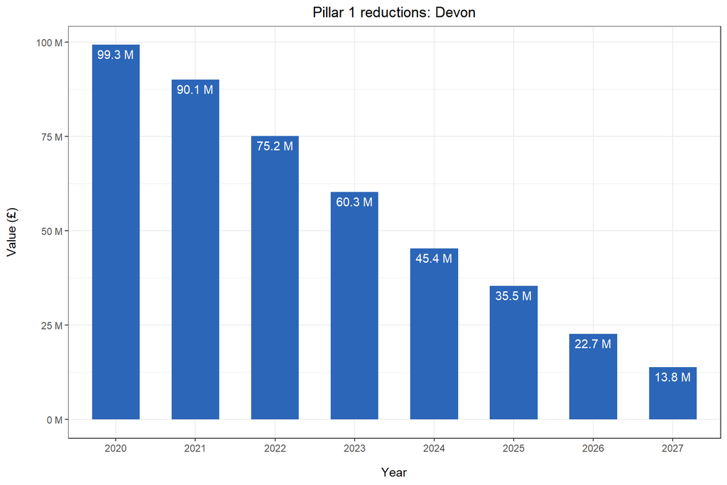

Table 1.3 P1 reductions by postcode district - Dorset

| PC | 2020_Unadjusted | Agri_In | Agri_Out | Agri_PC | 2020 | 2021 | 2022 | 2023 | 2024 | 2025 | 2026 | 2027 |
| --- | --- | --- | --- | --- | --- | --- | --- | --- | --- | --- | --- | --- |
| BA12 | 6346310.03 | 295.497 | 0.66 | 0.002 | 12692.62 | 10276.15 | 8372.25 | 6468.36 | 4564.47 | 3295.21 | 2191.08 | 1412.86 |
| BA21 | 237902.25 | 12.906 | 1.36 | 0.105 | 24979.74 | 23093.41 | 19346.45 | 15599.49 | 11852.53 | 9354.56 | 6244.93 | 3746.96 |
| BA22 | 2812398.19 | 175.078 | 17.10 | 0.098 | 275615.02 | 247215.89 | 205873.64 | 164531.38 | 123189.13 | 95627.63 | 61442.81 | 37611.78 |
| BA8 | 652094.50 | 38.458 | 1.62 | 0.042 | 27387.97 | 24637.10 | 20528.91 | 16420.71 | 12312.52 | 9573.72 | 6188.86 | 3779.13 |
| BA9 | 1238362.79 | 67.125 | 0.68 | 0.010 | 12383.63 | 11033.29 | 9175.75 | 7318.20 | 5460.66 | 4222.30 | 2819.53 | 1719.36 |
| BH10 | 18441.91 | 1.309 | 1.31 | 1.001 | 18460.35 | 17537.33 | 14768.28 | 11999.23 | 9230.18 | 7384.14 | 4615.09 | 2769.06 |
| BH15 | 1397.27 | 0.051 | 0.05 | 0.980 | 1369.32 | 1300.86 | 1095.46 | 890.07 | 684.67 | 547.73 | 342.33 | 205.40 |
| BH16 | 214147.37 | 21.405 | 21.41 | 1.000 | 214147.37 | 199302.94 | 167180.84 | 135058.73 | 102936.63 | 81521.89 | 53536.84 | 32122.11 |
| BH17 | 53650.86 | 0.705 | 0.70 | 0.993 | 53275.30 | 48287.61 | 40296.33 | 32305.03 | 24313.73 | 18986.20 | 13318.83 | 7991.30 |
| BH19 | 490262.12 | 28.404 | 28.37 | 0.999 | 489771.86 | 415393.98 | 341928.20 | 268462.42 | 194996.64 | 146019.45 | 90390.74 | 57439.66 |
| BH20 | 3190961.34 | 145.911 | 145.86 | 1.000 | 3190961.34 | 2643555.09 | 2164910.89 | 1686266.69 | 1207622.49 | 888526.36 | 602366.94 | 380957.51 |
| BH21 | 2516506.61 | 180.032 | 178.09 | 0.989 | 2488825.04 | 2070484.58 | 1697160.83 | 1323837.08 | 950513.32 | 701630.82 | 465576.90 | 295009.08 |
| BH22 | 56651.95 | 6.375 | 6.38 | 1.001 | 56708.60 | 53873.17 | 45366.88 | 36860.59 | 28354.31 | 22683.44 | 14177.15 | 8506.29 |
| BH23 | 600654.08 | 41.168 | 15.93 | 0.387 | 232453.13 | 195136.11 | 160268.14 | 125400.17 | 90532.20 | 67286.89 | 41478.33 | 26550.49 |
| BH24 | 861956.35 | 46.934 | 7.29 | 0.155 | 133603.23 | 117635.33 | 97594.84 | 77554.36 | 57513.87 | 44153.55 | 28779.34 | 17729.75 |
| BH25 | 250154.12 | 11.312 | 0.00 | 0.000 | 0.00 | 0.00 | 0.00 | 0.00 | 0.00 | 0.00 | 0.00 | 0.00 |
| BH31 | 16081.54 | 3.649 | 3.65 | 1.000 | 16081.54 | 15277.46 | 12865.23 | 10453.00 | 8040.77 | 6432.62 | 4020.39 | 2412.23 |
| BH7 | 155716.17 | 0.168 | 0.17 | 1.012 | 157584.76 | 118188.58 | 94550.86 | 70913.15 | 47275.43 | 31516.95 | 23637.72 | 15758.48 |
| BH8 | 40754.19 | 2.719 | 2.72 | 1.000 | 40754.19 | 36809.82 | 30696.69 | 24583.57 | 18470.44 | 14395.02 | 10188.55 | 6113.13 |
| BH9 | 7150.73 | 1.055 | 1.05 | 0.995 | 7114.98 | 6759.22 | 5691.98 | 4624.73 | 3557.48 | 2845.99 | 1778.74 | 1067.25 |
| DT1 | 321142.12 | 4.796 | 4.80 | 1.001 | 321463.26 | 260143.16 | 211923.67 | 163704.18 | 115484.69 | 83338.37 | 55307.14 | 35690.15 |
| DT10 | 2215501.44 | 112.858 | 112.17 | 0.994 | 2202208.43 | 1965869.25 | 1635537.99 | 1305206.72 | 974875.46 | 754654.61 | 487547.94 | 298829.18 |
| DT11 | 5268228.17 | 292.039 | 292.04 | 1.000 | 5268228.17 | 4387406.27 | 3597172.04 | 2806937.82 | 2016703.59 | 1489880.77 | 958786.31 | 611098.86 |
| DT2 | 11058244.50 | 541.513 | 541.39 | 1.000 | 11058244.50 | 9217476.53 | 7558739.86 | 5900003.18 | 4241266.51 | 3135442.06 | 2049903.67 | 1301407.95 |
| DT3 | 772281.56 | 83.856 | 83.86 | 1.000 | 772281.56 | 700608.06 | 584765.83 | 468923.59 | 353081.36 | 275853.20 | 178561.59 | 108587.83 |
| DT4 | 98837.48 | 2.798 | 2.80 | 1.001 | 98936.32 | 82183.82 | 67343.38 | 52502.93 | 37662.47 | 27768.85 | 16863.63 | 10905.22 |
| DT5 | 6850.52 | 4.455 | 4.44 | 0.997 | 6829.97 | 6488.47 | 5463.98 | 4439.48 | 3414.98 | 2731.99 | 1707.49 | 1024.50 |
| DT6 | 3036994.48 | 158.966 | 158.59 | 0.998 | 3030920.49 | 2685929.95 | 2231291.88 | 1776653.80 | 1322015.73 | 1018923.68 | 645108.70 | 398327.36 |
| DT7 | 238968.44 | 16.753 | 1.44 | 0.086 | 20551.29 | 18088.45 | 15005.76 | 11923.06 | 8840.37 | 6785.24 | 4303.94 | 2665.75 |
| DT8 | 1105528.16 | 75.156 | 74.20 | 0.987 | 1091156.29 | 1001781.97 | 838108.53 | 674435.09 | 510761.64 | 401646.02 | 258597.52 | 156577.67 |
| DT9 | 3850902.00 | 175.569 | 146.50 | 0.834 | 3211652.27 | 2788947.75 | 2307199.91 | 1825452.07 | 1343704.23 | 1022539.00 | 664634.44 | 412608.53 |
| EX13 | 2276377.07 | 111.911 | 3.44 | 0.031 | 70567.69 | 65156.28 | 54571.12 | 43985.97 | 33400.82 | 26344.05 | 16846.63 | 10187.51 |
| SP5 | 6376124.67 | 337.513 | 44.94 | 0.133 | 848024.58 | 694610.34 | 567406.65 | 440202.96 | 312999.27 | 228196.82 | 148540.76 | 95470.99 |
| SP6 | 2077494.82 | 103.099 | 9.11 | 0.088 | 182819.54 | 153505.47 | 126082.54 | 98659.61 | 71236.68 | 52954.72 | 34962.62 | 22051.80 |
| SP7 | 1987764.70 | 116.721 | 64.70 | 0.554 | 1101221.64 | 988172.61 | 822989.36 | 657806.12 | 492622.87 | 382500.71 | 246788.04 | 150924.56 |
| SP8 | 1209961.34 | 73.093 | 70.14 | 0.960 | 1161562.89 | 1082177.87 | 907943.43 | 733709.00 | 559474.57 | 443318.28 | 284630.27 | 171354.20 |
| TA18 | 1030727.57 | 51.620 | 4.59 | 0.089 | 91734.75 | 80285.49 | 66525.28 | 52765.07 | 39004.85 | 29831.38 | 19711.00 | 12148.87 |
| TA20 | 2159808.09 | 117.094 | 19.12 | 0.163 | 352048.72 | 315555.75 | 262748.44 | 209941.13 | 157133.82 | 121928.95 | 76690.67 | 47146.55 |

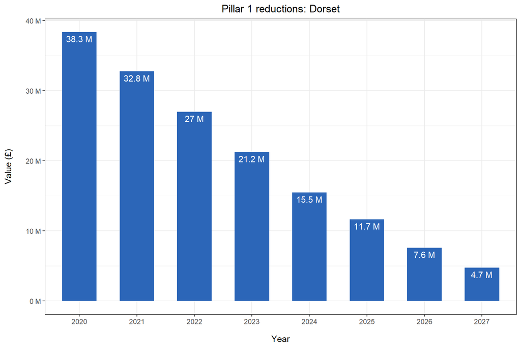

Table 1.4 P1 reductions by postcode district - Somerset

| PC | 2020_Unadjusted | Agri_In | Agri_Out | Agri_PC | 2020 | 2021 | 2022 | 2023 | 2024 | 2025 | 2026 | 2027 |
| --- | --- | --- | --- | --- | --- | --- | --- | --- | --- | --- | --- | --- |
| BA1 | 1317599.99 | 42.662 | 35.80 | 0.839 | 1105466.39 | 936981.26 | 771161.30 | 605341.34 | 439521.38 | 328974.75 | 214309.49 | 134791.41 |
| BA10 | 783558.26 | 43.613 | 43.51 | 0.998 | 781991.14 | 692668.34 | 575369.66 | 458070.99 | 340772.32 | 262573.21 | 165622.85 | 102361.20 |
| BA11 | 2127620.07 | 115.923 | 114.02 | 0.984 | 2093578.15 | 1865741.39 | 1551704.67 | 1237667.95 | 923631.23 | 714273.41 | 455995.13 | 280337.02 |
| BA12 | 6346310.03 | 295.497 | 1.15 | 0.004 | 25385.24 | 20552.30 | 16744.51 | 12936.72 | 9128.94 | 6590.41 | 4382.16 | 2825.71 |
| BA13 | 820881.86 | 63.448 | 0.81 | 0.013 | 10671.46 | 9237.62 | 7636.90 | 6036.18 | 4435.46 | 3368.32 | 2145.41 | 1339.49 |
| BA14 | 1248966.35 | 65.935 | 0.74 | 0.011 | 13738.63 | 12072.86 | 10012.06 | 7951.27 | 5890.47 | 4516.61 | 2843.26 | 1765.09 |
| BA15 | 574707.38 | 31.390 | 0.72 | 0.023 | 13218.27 | 11398.54 | 9415.80 | 7433.06 | 5450.32 | 4128.49 | 2556.94 | 1608.93 |
| BA16 | 372739.20 | 20.284 | 20.28 | 1.000 | 372739.20 | 344620.29 | 288709.41 | 232798.53 | 176887.65 | 139613.73 | 88154.60 | 53395.78 |
| BA2 | 1931256.06 | 120.317 | 117.18 | 0.974 | 1881043.40 | 1651047.58 | 1368891.08 | 1086734.57 | 804578.06 | 616473.71 | 391000.13 | 242526.16 |
| BA20 | 64409.18 | 2.669 | 2.67 | 1.000 | 64409.18 | 61188.72 | 51527.34 | 41865.97 | 32204.59 | 25763.67 | 16102.30 | 9661.38 |
| BA21 | 237902.25 | 12.906 | 11.55 | 0.895 | 212922.51 | 196843.86 | 164905.48 | 132967.10 | 101028.73 | 79736.47 | 53230.63 | 31938.38 |
| BA22 | 2812398.19 | 175.078 | 157.98 | 0.902 | 2536783.17 | 2275395.23 | 1894877.75 | 1514360.29 | 1133842.81 | 880164.49 | 565524.61 | 346181.89 |
| BA3 | 3760736.13 | 112.129 | 112.13 | 1.000 | 3760736.13 | 3362431.13 | 2798320.71 | 2234210.29 | 1670099.87 | 1294026.26 | 821976.70 | 505006.75 |
| BA4 | 2751068.31 | 146.960 | 146.96 | 1.000 | 2751068.31 | 2415479.97 | 2002819.72 | 1590159.47 | 1177499.23 | 902392.40 | 586463.86 | 362008.64 |
| BA5 | 1690939.49 | 115.837 | 115.84 | 1.000 | 1690939.49 | 1528378.10 | 1274737.17 | 1021096.25 | 767455.33 | 598361.38 | 382991.34 | 233769.16 |
| BA6 | 1390647.45 | 76.215 | 76.22 | 1.000 | 1390647.45 | 1240386.27 | 1031789.15 | 823192.03 | 614594.91 | 475530.17 | 301497.93 | 185515.15 |
| BA7 | 379069.44 | 24.908 | 24.91 | 1.000 | 379069.44 | 340820.01 | 283959.60 | 227099.18 | 170238.76 | 132331.82 | 87658.99 | 53306.23 |
| BA8 | 652094.50 | 38.458 | 36.84 | 0.958 | 624706.53 | 561960.63 | 468254.65 | 374548.67 | 280842.69 | 218372.04 | 141165.04 | 86200.19 |
| BA9 | 1238362.79 | 67.125 | 66.40 | 0.989 | 1224740.80 | 1091192.70 | 907481.58 | 723770.45 | 540059.34 | 417585.26 | 278851.66 | 170044.35 |
| BS13 | 10404.83 | 2.755 | 1.88 | 0.682 | 7096.09 | 6741.29 | 5676.87 | 4612.46 | 3548.05 | 2838.44 | 1774.03 | 1064.41 |
| BS14 | 81151.54 | 6.419 | 6.11 | 0.952 | 77256.27 | 73393.45 | 61805.01 | 50216.57 | 38628.13 | 30902.51 | 19314.06 | 11588.44 |
| BS15 | 10534.54 | 1.762 | 0.22 | 0.125 | 1316.82 | 1250.98 | 1053.45 | 855.93 | 658.41 | 526.73 | 329.20 | 197.52 |
| BS20 | 199815.22 | 17.663 | 17.66 | 1.000 | 199815.22 | 188009.81 | 158037.52 | 128065.24 | 98092.96 | 78111.44 | 49953.80 | 29972.28 |
| BS21 | 548234.79 | 31.763 | 31.76 | 1.000 | 548234.79 | 505671.30 | 423436.08 | 341200.86 | 258965.64 | 204142.16 | 130747.15 | 79079.45 |
| BS22 | 179628.40 | 14.406 | 14.41 | 1.000 | 179628.40 | 170646.98 | 143702.72 | 116758.46 | 89814.20 | 71851.36 | 44907.10 | 26944.26 |
| BS23 | 2872.94 | 2.148 | 2.15 | 1.001 | 2875.81 | 2732.02 | 2300.65 | 1869.28 | 1437.91 | 1150.33 | 718.96 | 431.37 |
| BS24 | 773092.66 | 46.867 | 46.87 | 1.000 | 773092.66 | 698733.71 | 582769.81 | 466805.91 | 350842.01 | 273532.74 | 173936.27 | 106295.45 |
| BS25 | 262358.33 | 19.462 | 19.46 | 1.000 | 262358.33 | 247070.08 | 207716.33 | 168362.58 | 129008.83 | 102772.99 | 65589.58 | 39353.75 |
| BS26 | 654617.58 | 42.396 | 42.40 | 1.000 | 654617.58 | 614658.27 | 516465.63 | 418273.00 | 320080.36 | 254618.60 | 163654.39 | 98192.64 |
| BS27 | 315526.19 | 23.393 | 23.39 | 1.000 | 315526.19 | 298153.06 | 250824.14 | 203495.21 | 156166.28 | 124613.66 | 78881.55 | 47328.93 |
| BS28 | 818646.31 | 45.860 | 45.86 | 1.000 | 818646.31 | 758089.58 | 635292.64 | 512495.69 | 389698.74 | 307834.11 | 198527.79 | 119730.05 |
| BS29 | 136999.89 | 10.349 | 10.35 | 1.000 | 136999.89 | 130149.90 | 109599.91 | 89049.93 | 68499.94 | 54799.96 | 34249.97 | 20549.98 |
| BS3 | 60737.92 | 1.009 | 0.47 | 0.466 | 28303.87 | 22730.02 | 18484.44 | 14238.86 | 9993.28 | 7162.89 | 4303.53 | 2859.36 |
| BS30 | 318622.86 | 32.179 | 0.87 | 0.027 | 8602.82 | 8172.68 | 6882.25 | 5591.83 | 4301.41 | 3441.13 | 2150.70 | 1290.42 |
| BS31 | 277742.52 | 17.951 | 17.10 | 0.953 | 264688.62 | 238610.11 | 198906.82 | 159203.53 | 119500.23 | 93031.37 | 59187.89 | 36211.16 |
| BS39 | 804731.30 | 65.493 | 65.49 | 1.000 | 804731.30 | 711470.72 | 590761.02 | 470051.33 | 349341.63 | 268868.50 | 175814.25 | 108025.41 |
| BS4 | 7065.85 | 0.694 | 0.02 | 0.029 | 204.91 | 194.66 | 163.93 | 133.19 | 102.45 | 81.96 | 51.23 | 30.74 |
| BS40 | 1926969.72 | 123.740 | 123.74 | 1.000 | 1926969.72 | 1718103.55 | 1429058.09 | 1140012.63 | 850967.17 | 658270.20 | 425627.94 | 260988.21 |
| BS41 | 302196.87 | 12.967 | 12.82 | 0.989 | 298872.70 | 268659.52 | 223828.61 | 178997.71 | 134166.80 | 104279.53 | 69751.93 | 42347.78 |
| BS48 | 662720.47 | 39.377 | 39.38 | 1.000 | 662720.47 | 619520.94 | 520112.87 | 420704.80 | 321296.73 | 255024.68 | 165680.12 | 99408.07 |
| BS49 | 445168.44 | 20.350 | 20.35 | 1.000 | 445168.44 | 414162.57 | 347387.30 | 280612.03 | 213836.77 | 169319.92 | 105460.48 | 63859.45 |
| BS8 | 282824.38 | 11.121 | 11.12 | 1.000 | 282824.38 | 264712.79 | 222289.13 | 179865.47 | 137441.82 | 109159.38 | 70706.10 | 42423.66 |
| BS9 | 14657.62 | 0.409 | 0.38 | 0.929 | 13616.93 | 12936.08 | 10893.55 | 8851.00 | 6808.46 | 5446.77 | 3404.23 | 2042.54 |
| DT10 | 2215501.44 | 112.858 | 0.69 | 0.006 | 13293.01 | 11866.41 | 9872.46 | 7878.51 | 5884.56 | 4555.26 | 2942.95 | 1803.80 |
| DT2 | 11058244.50 | 541.513 | 0.10 | 0.000 | 0.00 | 0.00 | 0.00 | 0.00 | 0.00 | 0.00 | 0.00 | 0.00 |
| DT8 | 1105528.16 | 75.156 | 0.95 | 0.013 | 14371.87 | 13194.70 | 11038.92 | 8883.14 | 6727.36 | 5290.17 | 3406.05 | 2062.32 |
| DT9 | 3850902.00 | 175.569 | 29.07 | 0.166 | 639249.73 | 555114.30 | 459226.84 | 363339.38 | 267451.92 | 203526.95 | 132289.35 | 82125.92 |
| EX13 | 2276377.07 | 111.911 | 1.04 | 0.009 | 20487.39 | 18916.34 | 15843.23 | 12770.12 | 9697.01 | 7648.27 | 4890.96 | 2957.66 |
| EX14 | 3584346.54 | 186.890 | 0.76 | 0.004 | 14337.39 | 13205.98 | 11055.37 | 8904.76 | 6754.16 | 5320.42 | 3379.78 | 2048.33 |
| EX15 | 3044385.84 | 167.143 | 1.10 | 0.007 | 21310.70 | 19928.31 | 16731.70 | 13535.10 | 10338.49 | 8207.42 | 5288.73 | 3177.13 |
| EX16 | 6005179.21 | 325.694 | 2.74 | 0.008 | 48041.43 | 44748.48 | 37542.27 | 30336.05 | 23129.84 | 18325.69 | 11639.92 | 7021.00 |
| EX35 | 653966.01 | 54.251 | 8.38 | 0.154 | 100710.77 | 88470.69 | 73364.08 | 58257.46 | 43150.85 | 33079.77 | 20787.05 | 12911.29 |
| EX36 | 4654512.01 | 226.749 | 9.90 | 0.044 | 204798.53 | 185175.58 | 154455.80 | 123736.02 | 93016.24 | 72536.39 | 46353.21 | 28296.57 |
| SN13 | 864110.22 | 39.210 | 0.18 | 0.005 | 4320.55 | 3828.63 | 3180.55 | 2532.47 | 1884.38 | 1452.33 | 970.20 | 593.12 |
| SN14 | 2795932.20 | 167.304 | 0.02 | 0.000 | 0.00 | 0.00 | 0.00 | 0.00 | 0.00 | 0.00 | 0.00 | 0.00 |
| SP8 | 1209961.34 | 73.093 | 2.33 | 0.032 | 38718.76 | 36072.60 | 30264.78 | 24456.97 | 18649.15 | 14777.28 | 9487.68 | 5711.81 |
| TA1 | 583543.77 | 3.439 | 3.44 | 1.000 | 583543.77 | 463194.84 | 375663.28 | 288131.71 | 200600.15 | 142245.77 | 97741.11 | 63459.15 |
| TA10 | 2109692.92 | 99.423 | 99.42 | 1.000 | 2109692.92 | 1925927.87 | 1609473.93 | 1293019.99 | 976566.05 | 765596.76 | 495036.55 | 300260.60 |
| TA11 | 1073232.78 | 75.066 | 75.07 | 1.000 | 1073232.78 | 967715.24 | 806730.32 | 645745.41 | 484760.49 | 377437.21 | 240518.34 | 147089.99 |
| TA12 | 558660.27 | 27.257 | 27.26 | 1.000 | 558660.27 | 506390.68 | 422591.64 | 338792.60 | 254993.56 | 199127.54 | 127181.38 | 77557.20 |
| TA13 | 460559.01 | 21.453 | 21.45 | 1.000 | 460559.01 | 412193.56 | 343109.71 | 274025.86 | 204942.00 | 158886.10 | 101043.32 | 62035.64 |
| TA14 | 177904.61 | 10.714 | 10.71 | 1.000 | 177904.61 | 157532.63 | 130846.94 | 104161.25 | 77475.56 | 59685.10 | 38461.99 | 23678.61 |
| TA15 | 29031.53 | 3.646 | 3.65 | 1.001 | 29060.56 | 27607.53 | 23248.45 | 18889.36 | 14530.29 | 11624.22 | 7265.14 | 4359.08 |
| TA16 | 86162.14 | 4.651 | 4.65 | 1.000 | 86162.14 | 81854.03 | 68929.71 | 56005.39 | 43081.07 | 34464.86 | 21540.54 | 12924.32 |
| TA17 | 178279.32 | 13.211 | 13.21 | 1.000 | 178279.32 | 147100.00 | 120358.11 | 93616.21 | 66874.31 | 49046.38 | 29726.26 | 19320.11 |
| TA18 | 1030727.57 | 51.620 | 47.03 | 0.911 | 938992.82 | 821798.70 | 680949.78 | 540100.85 | 399251.93 | 305352.65 | 201760.92 | 124355.28 |
| TA19 | 1411625.94 | 72.381 | 72.38 | 1.000 | 1411625.94 | 1240763.41 | 1029019.52 | 817275.63 | 605531.74 | 464369.14 | 301098.96 | 185840.13 |
| TA2 | 818663.67 | 38.814 | 38.81 | 1.000 | 818663.67 | 731050.62 | 608251.07 | 485451.52 | 362651.97 | 280785.60 | 184573.91 | 112753.55 |
| TA20 | 2159808.09 | 117.094 | 95.20 | 0.813 | 1755923.98 | 1573906.89 | 1310518.29 | 1047129.69 | 783741.10 | 608148.70 | 382512.35 | 235154.27 |
| TA21 | 1879680.39 | 95.112 | 72.94 | 0.767 | 1441714.86 | 1322394.89 | 1106137.66 | 889880.43 | 673623.20 | 529451.72 | 338115.44 | 205100.59 |
| TA22 | 1853621.93 | 93.611 | 77.68 | 0.830 | 1538506.20 | 1371730.15 | 1140954.22 | 910178.29 | 679402.36 | 525551.74 | 340177.36 | 208551.34 |
| TA23 | 740420.68 | 48.578 | 48.58 | 1.000 | 740420.68 | 682778.47 | 571715.37 | 460652.27 | 349589.16 | 275547.10 | 177352.78 | 107186.91 |
| TA24 | 3715605.73 | 270.566 | 259.18 | 0.958 | 3559550.29 | 3147518.98 | 2613586.44 | 2079653.89 | 1545721.35 | 1189766.32 | 766974.92 | 472476.22 |
| TA3 | 2697932.22 | 168.419 | 165.89 | 0.985 | 2657463.24 | 2398177.56 | 1999558.08 | 1600938.59 | 1202319.10 | 936572.78 | 601587.10 | 367230.12 |
| TA4 | 4151861.21 | 254.604 | 251.95 | 0.990 | 4110342.60 | 3744624.40 | 3128073.01 | 2511521.62 | 1894970.24 | 1483935.97 | 948166.86 | 576841.99 |
| TA5 | 2925401.70 | 146.607 | 146.61 | 1.000 | 2925401.70 | 2579174.07 | 2140363.81 | 1701553.56 | 1262743.30 | 970203.13 | 634622.56 | 390446.32 |
| TA6 | 733241.99 | 29.051 | 29.05 | 1.000 | 733241.99 | 671836.35 | 561850.06 | 451863.76 | 341877.46 | 268553.26 | 172014.72 | 104338.41 |
| TA7 | 2616149.68 | 165.078 | 165.08 | 1.000 | 2616149.68 | 2393421.48 | 2000999.03 | 1608576.58 | 1216154.13 | 954539.16 | 617416.55 | 374112.02 |
| TA8 | 229119.70 | 10.372 | 10.34 | 0.997 | 228432.34 | 208333.83 | 174068.97 | 139804.13 | 105539.27 | 82696.04 | 51323.49 | 31372.55 |
| TA9 | 1067636.38 | 65.504 | 65.50 | 1.000 | 1067636.38 | 1007790.37 | 847644.91 | 687499.45 | 527354.00 | 420590.36 | 266909.10 | 160145.46 |

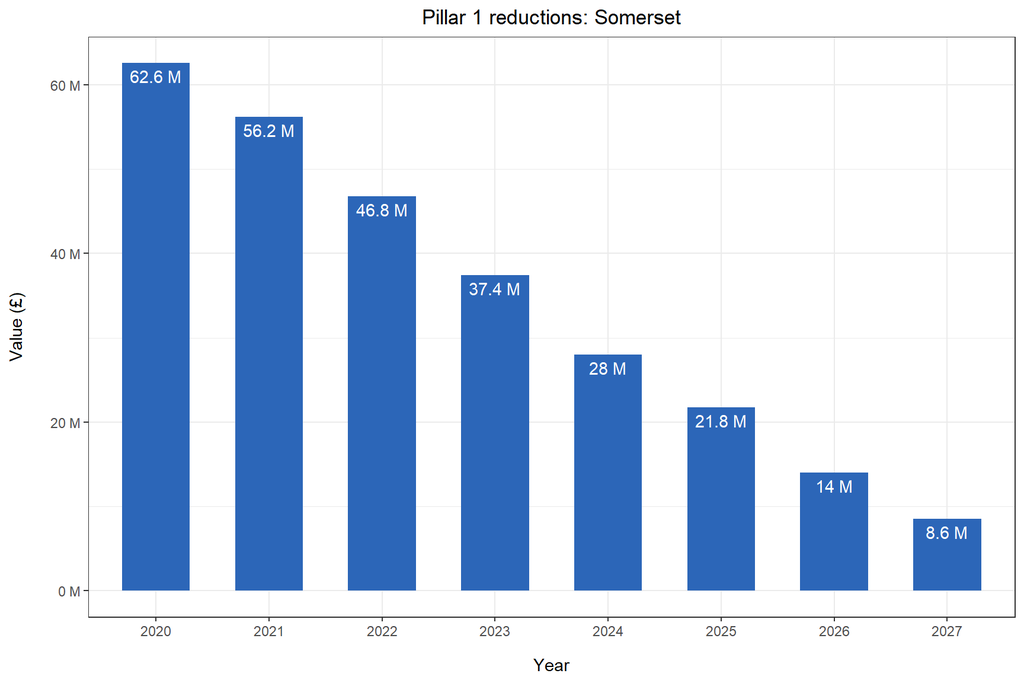

## 2. Pillar 1: District-level

*NTS - clip the districts to county boundary*

## 3. Agri-Environment

## 4. Agri land proportions calcs

Summary of Corine land cover types (all) by:

- County level
- District level
- Agri land classification areas / maps
- Summary ofAll CORINE types